# MLB Pitches

Zhicong Fan (zhicong2@illinois.edu)

11/29/2020

```
##        pitch_type         game_date     release_speed     release_pos_x
##       "character"            "Date"         "numeric"         "numeric"
##     release_pos_y     release_pos_z       player_name            batter
##         "numeric"         "numeric"       "character"         "numeric"
##           pitcher              zone             stand          p_throws
##         "numeric"         "numeric"       "character"       "character"
##             pfx_x             pfx_z           plate_x           plate_z
##         "numeric"         "numeric"         "numeric"         "numeric"
##               vx0               vy0               vz0                ax
##         "numeric"         "numeric"         "numeric"         "numeric"
##                ay                az   effective_speed release_spin_rate
##         "numeric"         "numeric"         "numeric"         "numeric"
## release_extension
##         "numeric"
```

## Abstract

> Baseball is an incredibly data-driven sport and we want to help with the future analyses.

## Introduction

Baseball is an interesting sport and even though I know little about this sport. I would like to dive into the dataset and explore more about predicting what type of ball is thrown. In this last analysis, I would like to apply the boosting strategy I learned in my research: XGBoost.

## Methods

Besides the knn and tree models, I am going to use XGB model in my final analysis.

### Data

There are 7 classes in this dataset: CH, CU, FF, FC FS, SI and SL. For the parameters, I am only going to use those except for batter, pitcher and game_date since these are either no relevant to my prediction or there exists another parameter could replace its role.

### Modeling

```
##
##    CH    CU    FC    FF    FS    SI    SL
## 24916 24725 13940 71831  3648 34248 37538
```

```
##
##   CH   CU   FC   FF   FS   SI   SL
##  812 1369  546 2805   95 1415 1419
```

[output not shown]

```
##             X1           X2           X3           X4           X5           X6
## 1 0.0001740226 3.599748e-05 0.0004345000 0.9808498025 2.379080e-05 0.0184278376
## 2 0.1044040546 1.501815e-04 0.0005863510 0.1116117910 8.351260e-03 0.7742112279
## 3 0.0040597734 4.552405e-05 0.0111607052 0.9813046455 6.375944e-04 0.0022727896
## 4 0.0007031944 1.241170e-02 0.1807961762 0.0005732812 4.323389e-04 0.0003168306
## 5 0.0006172141 4.978511e-05 0.0002568783 0.8600406647 9.192056e-05 0.1388323158
## 6 0.0107322205 7.892539e-05 0.0005949661 0.7697954178 1.109470e-04 0.2183816731
##             X7 max_prob label
## 1 5.406785e-05        4     4
## 2 6.851247e-04        6     4
## 3 5.190145e-04        4     4
## 4 8.047665e-01        7     3
## 5 1.111825e-04        4     4
## 6 3.057819e-04        4     4
```

```
## Confusion Matrix and Statistics
##
##           Reference
## Prediction     1     2     3     4     5     6     7
##          1 23421    34    18   171  1360   720    64
##          2    13 21808    60    17    14     6  1764
##          3    16    23  9161   630     3    16  1587
##          4   143     2  1010 68721    29  3715    70
##          5   338    12     6     7  2153    15    18
##          6   833     0     8  2210    68 29680     6
##          7   150  2911  3667    60    40    14 34049
##
## Overall Statistics
##
##                Accuracy : 0.8964
##                  95% CI : (0.8951, 0.8977)
##     No Information Rate : 0.3406
##     P-Value [Acc > NIR] : < 2.2e-16
##
##                   Kappa : 0.8688
##
##  Mcnemar's Test P-Value : < 2.2e-16
##
## Statistics by Class:
##
##                      Class: 1 Class: 2 Class: 3 Class: 4 Class: 5 Class: 6
## Sensitivity            0.9401   0.8797  0.65765   0.9569  0.58713   0.8687
## Specificity            0.9873   0.9899  0.98845   0.9643  0.99809   0.9823
## Pos Pred Value         0.9082   0.9209  0.80107   0.9326  0.84464   0.9047
## Neg Pred Value         0.9919   0.9841  0.97608   0.9774  0.99273   0.9748
## Precision              0.9082   0.9209  0.80107   0.9326  0.84464   0.9047
## Recall                 0.9401   0.8797  0.65765   0.9569  0.58713   0.8687
## F1                     0.9239   0.8998  0.72231   0.9446  0.69273   0.8864
## Prevalence             0.1182   0.1176  0.06607   0.3406  0.01739   0.1620
## Detection Rate         0.1111   0.1034  0.04345   0.3259  0.01021   0.1408
## Detection Prevalence   0.1223   0.1123  0.05424   0.3495  0.01209   0.1556
## Balanced Accuracy      0.9637   0.9348  0.82305   0.9606  0.79261   0.9255
##                      Class: 7
## Sensitivity            0.9066
## Specificity            0.9605
## Pos Pred Value         0.8327
## Neg Pred Value         0.9794
## Precision              0.8327
## Recall                 0.9066
## F1                     0.8681
## Prevalence             0.1781
## Detection Rate         0.1615
## Detection Prevalence   0.1939
## Balanced Accuracy      0.9335
```

```
## Confusion Matrix and Statistics
##
##           Reference
## Prediction     1     2     3     4     5     6     7
##          1  5868     3     4    49   319   163    12
##          2     5  5444     6     5     0     1   445
##          3     3     8  2297   164     0     1   388
##          4    53     1   246 17181     6   904    18
##          5    85     2     0     2   539     4     7
##          6   179     0     1   554    22  7567     0
##          7    37   658   940    17     6     3  8494
##
## Overall Statistics
##
##                Accuracy : 0.8991
##                  95% CI : (0.8965, 0.9016)
##     No Information Rate : 0.341
##     P-Value [Acc > NIR] : < 2.2e-16
##
##                   Kappa : 0.8722
##
##  Mcnemar's Test P-Value : NA
##
## Statistics by Class:
##
##                      Class: 1 Class: 2 Class: 3 Class: 4 Class: 5 Class: 6
## Sensitivity            0.9419   0.8901  0.65741   0.9560  0.60426   0.8755
## Specificity            0.9882   0.9901  0.98854   0.9647  0.99807   0.9828
## Pos Pred Value         0.9143   0.9218  0.80287   0.9333  0.84351   0.9092
## Neg Pred Value         0.9922   0.9856  0.97599   0.9769  0.99322   0.9758
## Precision              0.9143   0.9218  0.80287   0.9333  0.84351   0.9092
## Recall                 0.9419   0.8901  0.65741   0.9560  0.60426   0.8755
## F1                     0.9279   0.9057  0.72290   0.9445  0.70411   0.8920
## Prevalence             0.1182   0.1160  0.06629   0.3410  0.01692   0.1640
## Detection Rate         0.1113   0.1033  0.04358   0.3259  0.01023   0.1436
## Detection Prevalence   0.1218   0.1120  0.05428   0.3492  0.01212   0.1579
## Balanced Accuracy      0.9650   0.9401  0.82298   0.9603  0.80117   0.9292
##                      Class: 7
## Sensitivity            0.9071
## Specificity            0.9617
## Pos Pred Value         0.8364
## Neg Pred Value         0.9796
## Precision              0.8364
## Recall                 0.9071
## F1                     0.8703
## Prevalence             0.1776
## Detection Rate         0.1611
## Detection Prevalence   0.1927
## Balanced Accuracy      0.9344
```

```
##              Feature       Gain      Cover  Frequency
## 1:                az 0.30048886 0.09221692 0.05399230
## 2:                ax 0.16676620 0.12918495 0.07954545
## 3:             pfx_z 0.12993569 0.07177799 0.05519481
## 4: release_spin_rate 0.12523870 0.11340961 0.09770322
## 5:     release_pos_x 0.05293280 0.10510880 0.14267677
## 6:     release_speed 0.04681016 0.04750140 0.03228716
```

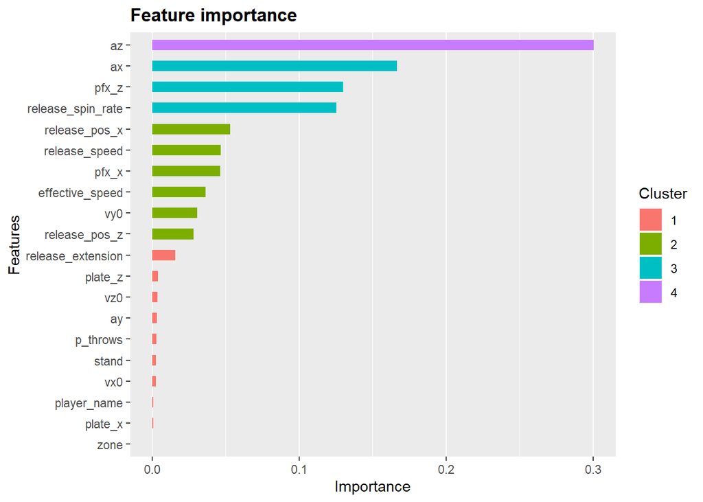

```
## Confusion Matrix and Statistics
##
##           Reference
## Prediction    1    2    3    4    5    6    7
##          1  851    0    1    1   43    2    0
##          2    1 1448    0    0    0    0   71
##          3    3    4  482   14    0    5   76
##          4   17    0   50 3401    1  176    7
##          5   29    0    1    0   68    0    1
##          6  110    0    0   89    4 1584    1
##          7    4  259  148    1    2    1 1617
##
## Overall Statistics
##
##                Accuracy : 0.8939
##                  95% CI : (0.8879, 0.8997)
##     No Information Rate : 0.3316
##     P-Value [Acc > NIR] : < 2.2e-16
##
##                   Kappa : 0.8656
##
##  Mcnemar's Test P-Value : NA
##
## Statistics by Class:
##
##                      Class: 1 Class: 2 Class: 3 Class: 4 Class: 5 Class: 6
## Sensitivity           0.83842   0.8463  0.70674   0.9701 0.576271   0.8959
## Specificity           0.99508   0.9919  0.98969   0.9645 0.997035   0.9768
## Pos Pred Value        0.94766   0.9526  0.82534   0.9313 0.686869   0.8859
## Neg Pred Value        0.98305   0.9709  0.97998   0.9848 0.995226   0.9791
## Precision             0.94766   0.9526  0.82534   0.9313 0.686869   0.8859
## Recall                0.83842   0.8463  0.70674   0.9701 0.576271   0.8959
## F1                    0.88970   0.8963  0.76145   0.9503 0.626728   0.8909
## Prevalence            0.09600   0.1618  0.06450   0.3316 0.011161   0.1672
## Detection Rate        0.08049   0.1370  0.04559   0.3217 0.006431   0.1498
## Detection Prevalence  0.08493   0.1438  0.05524   0.3454 0.009363   0.1691
## Balanced Accuracy     0.91675   0.9191  0.84822   0.9673 0.786653   0.9364
##                      Class: 7
## Sensitivity            0.9120
## Specificity            0.9528
## Pos Pred Value         0.7958
## Neg Pred Value         0.9817
## Precision              0.7958
## Recall                 0.9120
## F1                     0.8499
## Prevalence             0.1677
## Detection Rate         0.1529
## Detection Prevalence   0.1922
## Balanced Accuracy      0.9324
```

## Results

To my surprise, the most significant factors are a_z, a_x and pfx_z. I thought the player himself would have great effect on the result at the first time.

## Discussion

Using all the regular data, I achieved an accuracy of 89% of both predicting test data split from the regular season and the test data constructed by the whole post season. For the missing data, the max probability is the 6th move which is “SI”.